# Lesson 136 · Leaderboard literacy: reproduce the score, audit the setup

Teacher reference · Three live audit functions, full author evidence, optional complete replay and full five-seed training. Default notebook scoring is explicitly separated from fresh training.

```python
# @colab-bootstrap: install missing dependencies; report actual versions.
import importlib.util,importlib.metadata,subprocess,sys
required={'numpy':'numpy','pandas':'pandas','pyarrow':'pyarrow','torch':'torch','torch_frame':'pytorch-frame==0.2.3','torch_geometric':'torch-geometric==2.6.1','relbench':'relbench==1.1.0','pooch':'pooch'}
missing=[package for module,package in required.items() if importlib.util.find_spec(module) is None]
if missing:subprocess.check_call([sys.executable,'-m','pip','install',*missing])
print('Actual notebook runtime:',sys.version)
print({k:importlib.metadata.version(k) for k in ['numpy','pandas','torch','pytorch-frame','torch-geometric','relbench']})
```

```
Actual notebook runtime: 3.12.3 (main, Aug 31 2026, 10:18:26) [GCC 13.3.0]
{'numpy': '2.5.0', 'pandas': '3.0.3', 'torch': '2.13.0+cpu', 'pytorch-frame': '0.3.0', 'torch-geometric': '2.8.0.post1', 'relbench': '1.1.0'}
```

```python
import math,json,hashlib
from pathlib import Path
import numpy as np
import pandas as pd
import torch
from IPython.display import display
torch.set_num_threads(1)
def rejects(fn,*args):
    try:fn(*args)
    except ValueError:return
    raise AssertionError('Invalid evidence accepted')
```

Audit the score before explaining the rank

**Reading route.** Align queries → understand the metric → check task coverage → distinguish score replay from training.

**Quick prerequisite reminder**

A cutoff is the instant at which a prediction is made. A checkpoint stores a fitted model’s state. Validation chooses that state; test measures the frozen choice. A seed controls a run’s random choices, not which database it tests.

A leaderboard number is the last line of an experiment. Your job is to recover the contract behind that line.

**Your win:** independently reconstruct a leading entry’s regression score, produce a configuration-difference report, and say exactly which parts of its claim you have reproduced.

On a narrow screen, scroll diagrams horizontally to keep their labels readable.

**Route:** align one prediction table → trace normalization → audit board coverage → defend a claim. The core lesson takes about 45–60 minutes. Full author experiments are evidence to inspect; they do not count as your mastery.

[Student notebook](https://avistian.github.io/relational/labs/0136-leaderboard-literacy.ipynb) · [Executed reference](https://avistian.github.io/relational/labs/html/0136-leaderboard-literacy.html) · [Solution notebook](https://avistian.github.io/relational/labs/solutions/0136-leaderboard-literacy.ipynb) · [Reference card](https://avistian.github.io/relational/reference/leaderboard-literacy.html) · [Commands and evidence](https://avistian.github.io/relational/labs/l136-reproduction.md)

## 1 · From a fair search to a defensible comparison

[Lesson 135](https://avistian.github.io/relational/lessons/0135-tuning-on-reg.html) froze a search budget and used validation to select its winner. That protects one experiment. A leaderboard adds a harder question: did the other entry get the same information and resources?

Our mission is to make evidence for relational learning credible to a skeptic. Ranking a method is useful only after identifying what was ranked. This lesson therefore carries three separate statements through the same workflow: the score is correct; the training setup is recoverable; the comparison supports the claim. Each needs different evidence.

**Read first:** the [official submission contract](https://github.com/stanford-star/relbench/blob/584a03d518b2b655580ea8e1cfbbb26bec0a2841/relbench/submit.py). A submission supplies prediction tables. An entire task family must be present before that board is validated. The [public rules](https://star-project.stanford.edu/relbench/leaderboard/) restrict temporal information and target-database gradient training for in-context entries. They do not impose equal runtime or equal tuning budgets.

> **In plain terms.** A score validator checks the submitted answers. It cannot reconstruct every operation that produced those answers.

We freeze the repository at `584a03d…2841` and the hosted data at `d8e976f…8600`. The text returned by the leaderboard page said “No entries yet,” while the repository contained populated entries. That discrepancy is a reason to preserve the actual source, date and bytes; it is not evidence that the board has no submissions. [Pinned score snapshot](https://github.com/stanford-star/relbench/blob/584a03d518b2b655580ea8e1cfbbb26bec0a2841/leaderboard/leaderboard.json).

## 2 · The first job is identity, not arithmetic

A prediction table has **keys** identifying the question and a value giving the answer. For `rel-f1/driver-position`, the keys are `driverId` and `date`. The same driver appears at multiple cutoffs. Sorting by driver alone cannot recover the intended questions.

**Worked example.** The official query order is `(4,100), (4,200), (9,100)`. A submitted file orders these as `(9,100), (4,100), (4,200)` and gives predictions `30,10,20`. The correctly aligned vector is `10,20,30`. Reordering a valid file must leave the score unchanged.

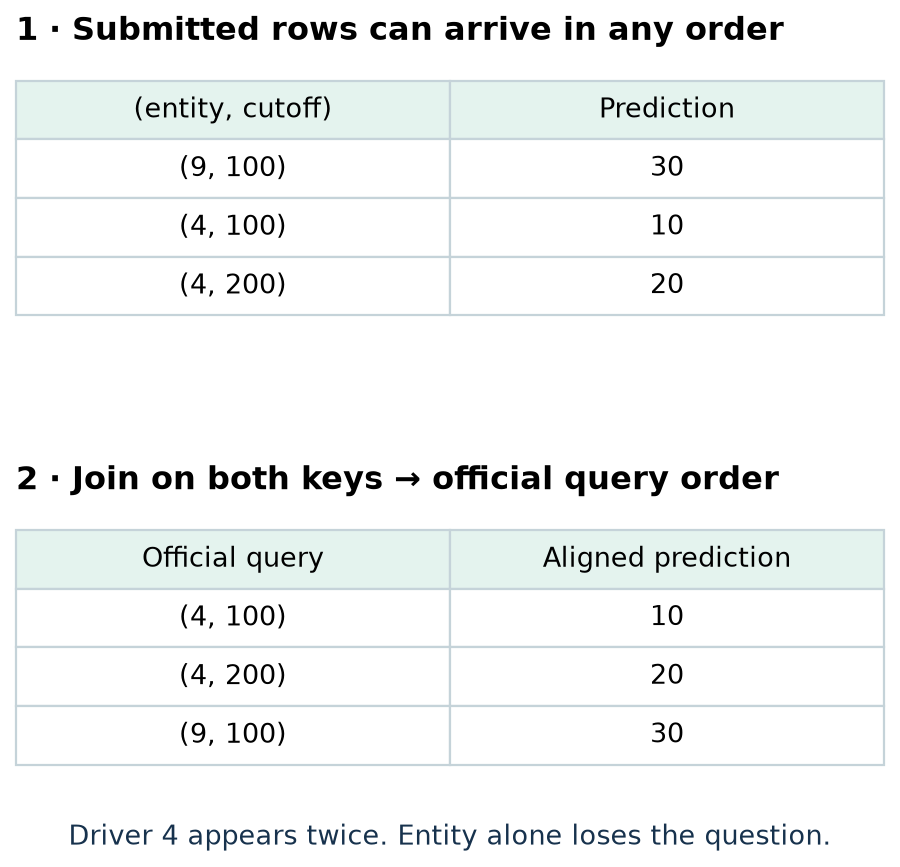

Synthetic keyed-row example: preserve both entity and cutoff, then recover official order.

A **bijection** here means that every official query has exactly one submitted answer and no answer refers to a foreign query. Reject duplicates instead of dropping them. Reject missing rows instead of scoring an easier subset. Reject nonfinite predictions instead of letting an undefined number pass through an average.

**TODO 1 — `align_predictions`:** validate both key sets, then return predictions in official order. Its CHECK includes repeated entities at different dates, duplicates, missing rows, extra rows and NaN. The same function is called on the published F1 predictions later.

```
def align_predictions(expected_keys, prediction_keys, predictions):
    """Return predictions in official query order after checking a bijection."""
    expected=[tuple(k) for k in expected_keys]
    supplied=[tuple(k) for k in prediction_keys]
    values=[float(v) for v in predictions]
    if not expected or len(supplied)!=len(values):
        raise ValueError('Empty queries or different key/value counts')
    for keys in [expected,supplied]:
        if any(not k or any(x is None or (isinstance(x,float) and not math.isfinite(x)) for x in k) for k in keys):
            raise ValueError('Missing query key')
        if len(set(keys))!=len(keys):
            raise ValueError('Duplicate query key; entity alone is not a temporal query')
    if set(expected)!=set(supplied):
        raise ValueError('Missing or foreign prediction keys')
    if not all(math.isfinite(x) for x in values):
        raise ValueError('Nonfinite prediction')
    lookup=dict(zip(supplied,values))
    return [lookup[k] for k in expected]
```

**Prediction before reveal:** if two CSV files have the same numbers in a different row order, are their scores necessarily the same?

**Reveal after committing**

Only if those numbers remain attached to the same entity–cutoff keys. Permuting entire keyed rows preserves the score; permuting values while keeping keys fixed changes the answers.

The reference scorer independently uses the pinned upstream key-validation and join functions. Every aligned prediction is compared exactly, not just its final average. [Released alignment code](https://github.com/stanford-star/relbench/blob/584a03d518b2b655580ea8e1cfbbb26bec0a2841/relbench/submit.py).

```python
def align_predictions(expected_keys, prediction_keys, predictions):
    """Return predictions in official query order after checking a bijection."""
    expected=[tuple(k) for k in expected_keys]
    supplied=[tuple(k) for k in prediction_keys]
    values=[float(v) for v in predictions]
    if not expected or len(supplied)!=len(values):
        raise ValueError('Empty queries or different key/value counts')
    for keys in [expected,supplied]:
        if any(not k or any(x is None or (isinstance(x,float) and not math.isfinite(x)) for x in k) for k in keys):
            raise ValueError('Missing query key')
        if len(set(keys))!=len(keys):
            raise ValueError('Duplicate query key; entity alone is not a temporal query')
    if set(expected)!=set(supplied):
        raise ValueError('Missing or foreign prediction keys')
    if not all(math.isfinite(x) for x in values):
        raise ValueError('Nonfinite prediction')
    lookup=dict(zip(supplied,values))
    return [lookup[k] for k in expected]
```

```python
def check_align(fn):
    keys=[(4,100),(4,200),(9,100)]
    assert fn(keys,[keys[2],keys[0],keys[1]],[30.,10.,20.])==[10.,20.,30.]
    for bad,values in [([keys[0],keys[0],keys[2]],[1,2,3]),(keys[:2],[1,2]),(keys+[(8,1)],[1,2,3,4]),(keys,[1,float('nan'),3]),(keys,[1,2])]:rejects(fn,keys,bad,values)
    rejects(fn,[keys[0],keys[0]],keys[:2],[1,2])
    rejects(fn,[(None,100)],[(None,100)],[1])
check_align(align_predictions)
print("PASS: align_predictions")
```

```
PASS: align_predictions
```

## 3 · Know what a unit of error means

**Mean absolute error (MAE)** averages the absolute difference between target and prediction. On finishing position, it is measured in positions. On revenue, it is measured in currency. An arithmetic average of these raw errors has no common unit.

The current regression board uses **normalized MAE (NMAE)**. It divides a task’s MAE by a fixed scale derived from that task’s training targets. The source specifies their sample standard deviation, which uses `n−1` in the variance denominator. The evaluator resolves a hosted per-task constant. It never estimates that scale from the submitted predictions. [Pinned metric implementation](https://github.com/stanford-star/relbench/blob/584a03d518b2b655580ea8e1cfbbb26bec0a2841/relbench/metrics.py).

> **In plain terms.** First measure the error in the task’s units. Then divide by a fixed training-data yardstick. Lower remains better.

**Worked example.** Targets `[0,2,4]` and predictions `[1,4,4]` have absolute errors `[1,2,0]`. Their MAE is `3/3 = 1`. With training-target standard deviation `2`, NMAE is `1/2 = 0.5`. Doubling the denominator to `4` makes the score `0.25` without improving any prediction. That is why the denominator belongs in the protocol.

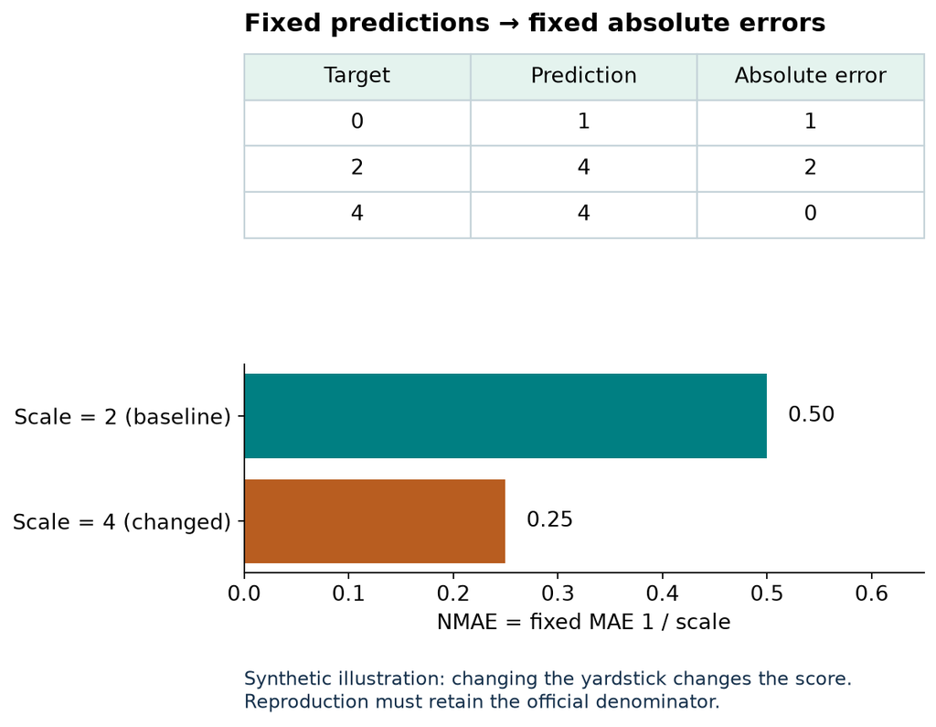

Synthetic fixed-error example: the scale changes NMAE while predictions remain identical.

Baseline MAE 1 / scale 2 = 0.500. Change scale to 4 → NMAE 0.250, with identical predictions.

**TODO 2 — `regression_score`:** compute MAE and NMAE from paired finite vectors and a finite positive scale. Reject invalid inputs. This function scores all three published F1 files in the notebook and every task in the complete replay operator.

```
def regression_score(targets, predictions, train_std):
    """NMAE uses the pinned train-target sample SD, never a test-fitted scale."""
    y=[float(v) for v in targets];p=[float(v) for v in predictions];scale=float(train_std)
    if not y or len(y)!=len(p) or not math.isfinite(scale) or scale<=0:
        raise ValueError('Need paired rows and a finite positive train scale')
    if not all(math.isfinite(v) for v in y+p):
        raise ValueError('Nonfinite target or prediction')
    mae=math.fsum(abs(a-b) for a,b in zip(y,p))/len(y)
    return dict(mae=mae,nmae=mae/scale,count=len(y))
```

For F1 the pinned denominator is **7.025733902396073**. A historical result of `4.022 MAE` would convert to approximately `0.5725 NMAE` using that scale. This is a unit conversion, not a reproduction of the current GNN entry.

**The audit found a real discrepancy.** For `rel-stack/post-votes`, the hosted constant is `0.5104313497537508`; recomputing sample SD from the pinned raw training parquet gives `0.5104212106119147`. The difference is small, but changing it would change the scores. We preserve the hosted constant to reproduce the board, record both values, and leave the cause unestablished. A passing prediction replay does not settle the constant’s derivation. [Pinned normalization table](https://huggingface.co/datasets/stanford-star/relbench-v1/blob/d8e976fd0a4b78877204bc8dfbcfc9a9f7f48600/regression_stds.json).

```python
def regression_score(targets, predictions, train_std):
    """NMAE uses the pinned train-target sample SD, never a test-fitted scale."""
    y=[float(v) for v in targets];p=[float(v) for v in predictions];scale=float(train_std)
    if not y or len(y)!=len(p) or not math.isfinite(scale) or scale<=0:
        raise ValueError('Need paired rows and a finite positive train scale')
    if not all(math.isfinite(v) for v in y+p):
        raise ValueError('Nonfinite target or prediction')
    mae=math.fsum(abs(a-b) for a,b in zip(y,p))/len(y)
    return dict(mae=mae,nmae=mae/scale,count=len(y))
```

```python
def check_metric(fn):
    r=fn([0,2,4],[1,4,4],2.)
    assert r['mae']==1. and r['nmae']==.5 and r['count']==3
    assert fn([0,2,4],[1,4,4],4.)['nmae']==.25
    for y,p,s in [([],[],2),([1],[1,2],2),([1],[2],0),([1],[2],-1),([1],[2],float('nan')),([1],[float('inf')],2)]:rejects(fn,y,p,s)
check_metric(regression_score)
print("PASS: regression_score")
```

```
PASS: regression_score
```

## 4 · A board is a declared set of tasks

The pinned regression board contains **nine tasks**. Each contributes one ninth of the aggregate, regardless of its number of test queries. This is an arithmetic mean of task NMAEs; it is not a mean of ranks and not a pooled average over every query.

**Worked example.** Two illustrative tasks have scores `0.1` and `0.5`. Their board mean is `(0.1+0.5)/2 = 0.3`. If the second task is omitted, `0.1` is only a partial mean. It is not a better complete-board result.

**Weighting can reverse the winner.** Consider two illustrative tasks with fixed normalization scales. Model A is better on the small task; B is better on the large task:

| Task | Queries | A NMAE | B NMAE |
| --- | --- | --- | --- |
| Small | 10 | 0.1 | 0.3 |
| Large | 90 | 0.9 | 0.8 |

An equal-task mean gives **A = 0.50, B = 0.55**, so A wins. Weighting each task by its query count gives **A = 0.82, B = 0.75**, so B wins. The latter averages per-query *normalized* errors; it does not mix raw errors in different units. These are two different declared objectives. The pinned board uses the first: each task has equal weight.

**Transfer check.** Duplicate every query in the large task while preserving predictions, labels and normalization. Its NMAE and the equal-task board score remain unchanged; a query-weighted score changes. Explain why a correct per-task score alone cannot establish that an aggregate implements the board's contract. Choose the weighting rule before comparing winners.

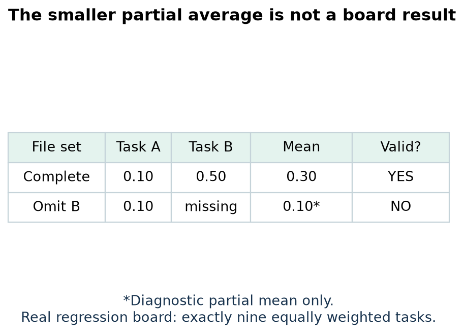

Synthetic two-task board: omitting the harder task produces an invalid partial average.

Both tasks [0.1, 0.5] → valid mean 0.300. Omit the second → partial mean 0.100, REJECT as incomplete.

**TODO 3 — `complete_board`:** require exactly the canonical task names, once each, then compute the equally weighted mean. The complete replay calls it on all nine measured scores for each entry. Missing and extra tasks must fail its CHECK.

```
def complete_board(scores, canonical_tasks):
    """Equal task weighting is allowed only for exactly the canonical task set."""
    tasks=list(canonical_tasks)
    if not tasks or len(set(tasks))!=len(tasks) or set(scores)!=set(tasks):
        raise ValueError('Incomplete, extra or duplicate board tasks')
    values=[float(scores[t]) for t in tasks]
    if not all(math.isfinite(v) and v>=0 for v in values):
        raise ValueError('Invalid regression score')
    return math.fsum(values)/len(values)
```

The official implementation can print a diagnostic average over available tasks while marking a board incomplete. Our learner function refuses to return a board score in that case. This deliberate interface difference prevents a partial diagnostic from being mistaken for a qualified entry. [Board-validation source](https://github.com/stanford-star/relbench/blob/584a03d518b2b655580ea8e1cfbbb26bec0a2841/relbench/submit.py).

```python
def complete_board(scores, canonical_tasks):
    """Equal task weighting is allowed only for exactly the canonical task set."""
    tasks=list(canonical_tasks)
    if not tasks or len(set(tasks))!=len(tasks) or set(scores)!=set(tasks):
        raise ValueError('Incomplete, extra or duplicate board tasks')
    values=[float(scores[t]) for t in tasks]
    if not all(math.isfinite(v) and v>=0 for v in values):
        raise ValueError('Invalid regression score')
    return math.fsum(values)/len(values)
```

```python
def check_board(fn):
    assert fn({'b':.3,'a':.1},['a','b'])==.2
    for scores,tasks in [({'a':.1},['a','b']),({'a':.1,'b':.3,'c':.2},['a','b']),({'a':float('nan')},['a']),({'a':.1},['a','a']),({},[])]:rejects(fn,scores,tasks)
check_board(complete_board)
print("PASS: complete_board")
```

```
PASS: complete_board
```

## 5 · Reconstruct the published numbers

**Prediction before reveal:** which is stronger evidence that a submitted score is correct: reading its displayed aggregate, or matching every query, independently rescoring all tasks, and reconstructing the mean?

We chose the regression leader in the captured repository snapshot, **Kapso**, plus **GNN** and **RT-PluRel (fine-tuned)** as comparison entries. We downloaded their actual submitted prediction archives and the official labels. We held prediction bytes, query identity, task coverage and normalization fixed. We varied only the implementation of alignment and scoring: the lesson’s visible functions versus pinned upstream functions.

**Complete archive evaluation replay.** Independently rescored **2,480,739 predictions across 27 task-entry pairs. Exact row-alignment agreement with pinned upstream functions; all task scores agree within `1e−10`.

| Entry | Recomputed mean NMAE | Tasks |
| --- | --- | --- |
| Kapso (Leeroo Team) | 0.247610406289 | 9/9 |
| RT-PluRel (fine-tuned) | 0.281392037401 | 9/9 |
| GNN | 0.312986490195 | 9/9 |

[Full task-by-task audit](https://avistian.github.io/relational/labs/evidence/l136/leaderboard.json). These are measured evaluation results from submitted files, not newly trained models.

The three archives are [Kapso #393](https://github.com/stanford-star/relbench/issues/393), [GNN #380](https://github.com/stanford-star/relbench/issues/380) and [RT-PluRel #397](https://github.com/stanford-star/relbench/issues/397). The notebook’s default run directly aligns and rescores all **760 F1 queries for each entry**, then reconstructs all three board means from the complete author audit. Its optional full-replay switch downloads and independently rescores every task. Default notebook execution is therefore not a fresh 27-task replay.

> **Scope check.** The recovered rank is conditional on the captured entries and metric. These archives do not contain repeated independent training seeds. Do not invent a seed interval from nine heterogeneous tasks, or describe the archive replay as training Kapso.

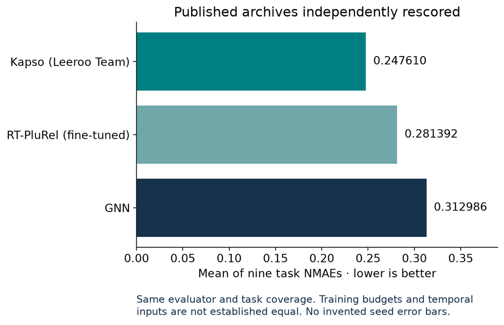

Measured archive replay: three complete nine-task entries; no equal-training-budget claim.

### CHECK · Use your three functions on actual submitted evidence

F1 predictions are embedded with hashes. All other task scores below come from the explicitly labeled complete author audit.

```python
# PROVIDED: full F1 submitted files in their original order, plus the full author board audit.
import base64,gzip,hashlib,json,io
raw=gzip.decompress(base64.b64decode('H4sIAAAAAAACA6292Y41uZWl+SqJ/6oKiHJwMJJGvUBfdKPQKNSdIDQEVFR3…'))
assert hashlib.sha256(raw).hexdigest()=='9ce40fc2325595d318fdb5e307f9841bdc4807cf7f32e3a091a046eebbabcf79'
F1=json.loads(raw)
AUTHOR_AUDIT=json.loads(gzip.decompress(base64.b64decode('H4sIAAAAAAACA81cW2+bOZL9K4afZoG2zSKLt56nbHd6O9hM0kgye8FiYRRv…=')))
truth=F1['truth'];entry_rows=[];predictions=0
for issue in ['393','380','397']:
    entry=F1[issue]
    aligned=align_predictions(truth['keys'],entry['keys'],entry['pred'])
    score=regression_score(truth['target'],aligned,truth['train_std'])
    assert abs(score['nmae']-entry['reported'])<1e-10
    # Row permutation must preserve the metric when keys travel with predictions.
    reverse=align_predictions(truth['keys'],entry['keys'][::-1],entry['pred'][::-1])
    assert aligned==reverse
    board=complete_board({t:AUTHOR_AUDIT['tasks'][t]['entries'][issue]['nmae'] for t in AUTHOR_AUDIT['canonical_tasks']},AUTHOR_AUDIT['canonical_tasks'])
    assert abs(board-AUTHOR_AUDIT['entries'][issue]['reported'])<1e-12
    entry_rows.append(dict(entry=entry['name'],f1_mae=score['mae'],f1_nmae=score['nmae'],board_mean=board));predictions+=score['count']
display(pd.DataFrame(entry_rows))
print('Directly rescored F1 predictions:',predictions)
print('Board reconstruction uses full author audit; enable full replay below to independently score all tasks.')
Path('l136-report.json').write_text(json.dumps(dict(status='PASS',direct_f1_predictions=predictions,board_task_scores_reaggregated=27,learner='PENDING_WRITTEN_DEFENSE'),indent=2))
```

|  | entry | f1_mae | f1_nmae | board_mean |
| --- | --- | --- | --- | --- |
| 0 | Kapso (Leeroo Team) | 2.417167 | 0.344045 | 0.247610 |
| 1 | GNN | 4.062226 | 0.578192 | 0.312986 |
| 2 | RT-PluRel (fine-tuned) | 2.736014 | 0.389428 | 0.281392 |

```
Directly rescored F1 predictions: 2280
Board reconstruction uses full author audit; enable full replay below to independently score all tasks.
```

```
135
```

## 6 · Recover the setup before explaining the gap

**Frozen database** means every test query reads from one database snapshot at the test boundary. **Rolling-time evaluation** means a later query may use later-arriving history, provided it precedes that query’s own cutoff. Both aim to exclude future information, but they provide different histories to late test queries.

**Worked example.** A model predicts at time `14`. A related event happened at `12`. A database frozen at `10` hides that event. A strictly past rolling view includes it. The prediction target and scoring rule can remain unchanged while the available input changes.

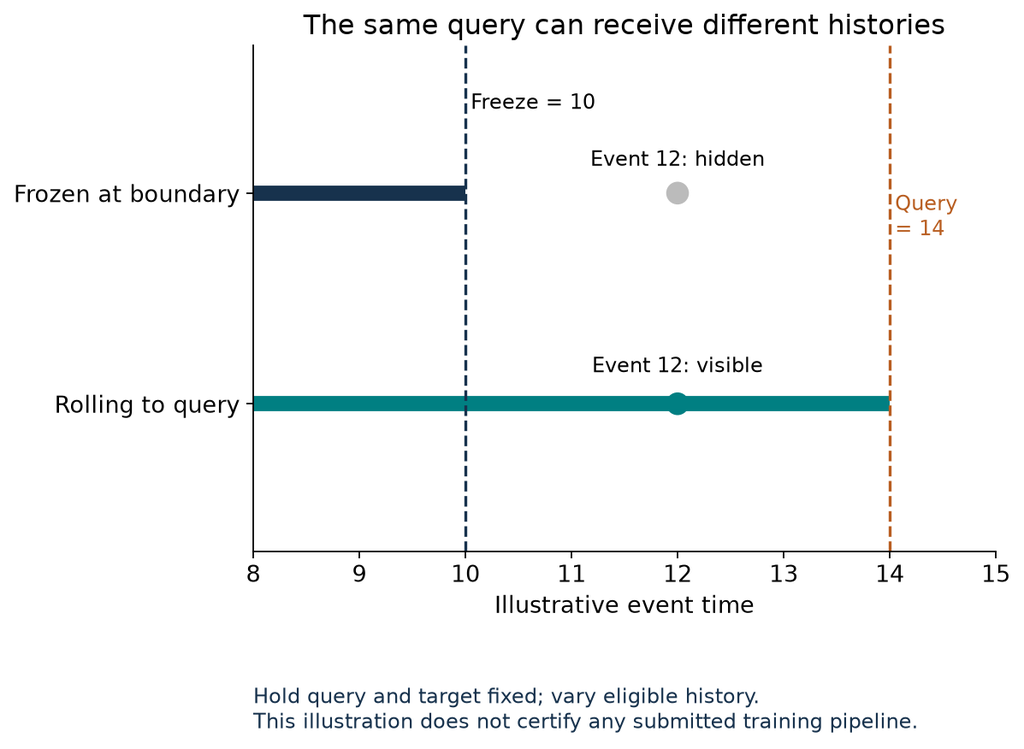

Synthetic query at time 14: event 12 is hidden by a snapshot frozen at 10 but visible in strictly past rolling history.

Kapso’s [released evaluation protocol](https://github.com/Leeroo-AI/kapso/blob/30ddb51cb971a105f37d4089c447af59e3d1e861/benchmarks/relbench/EVALUATION_PROTOCOL.md) explicitly discusses these regimes and their relevance to F1. This is the authors’ protocol description, not an independent audit of every submitted model. Its documented comparisons and the submitted F1 score are different artifacts; we do not assume they identify the same run.

**Configuration-difference report.** Use evidence identifiers, not a checkbox saying “same benchmark.”

| Dimension | Historical RDL lane we train | Current submitted-entry replay |
| --- | --- | --- |
| Data identity | Hash-pinned release archives | Revision-pinned hosted task tables and attached CSVs |
| Metric | Raw MAE; five-fit mean and sample SD | NMAE; one score per task, nine-task arithmetic mean |
| Model/trainer | Visible released RDL port, pinned runtime | Submitted answers recoverable; exact generating setup requires separate evidence |
| Selection | First minimum validation checkpoint, ten epochs | Selection procedure cannot be inferred from predictions |
| Temporal inputs | Released frozen database and inclusive node-time sampler | Must audit each entry’s actual feature and cutoff path |
| Search and cost | Fixed default, seeds 0–4, recorded budget | Equal effort not required by board rules |
| Identity claim | Released-protocol selected experiment | Evaluation of submitted files |

**A subtle boundary.** The historical sampler admits nodes timestamped at or before the root cutoff. The current public rule says information “at or in the future” is off-limits. Preserve the historical source when reproducing it, document the difference, and do not certify those fits as a compliant new leaderboard submission. Equal timestamps and real availability require their own audit.

## 7 · Fresh training supplies a different kind of evidence

To keep full reproduction concrete, we also ran the complete selected **RelBench v1 Table 7 basic RDL, `rel-f1/driver-position`** experiment. Every fit uses all **7,453 training queries per epoch**, **499 validation queries**, **760 test queries**, ten epochs, and one of seeds `0–4`.

The model is the visible released port used in earlier lessons: typed row features → table-specific Frame encoders plus relative-time encodings → two 128-channel typed GraphSAGE layers → seed-row regression head. It uses sum aggregation, Adam at `0.005`, batch size `512`, fanouts `[128,64]`, mean absolute training loss, and training-label percentile clipping for evaluation. The notebook includes the model, graph construction, trainer and full-data entrypoint, rather than hiding them behind one import.

Validation chooses the first minimum checkpoint. Its weights are restored before final scoring. Temporal sampling is stochastic, so the selected checkpoint’s replayed validation score can differ slightly from its selection trace; both are saved. Test never chooses a checkpoint. The official test split has been used in previous lessons, so fresh seeds do not create a new untouched test set.

**Five fresh full-data fits completed.**

| Split | Fresh mean ± sample SD (MAE) | Paper mean | Descriptive verdict |
| --- | --- | --- | --- |
| val | 3.187927 ± 0.025788 | 3.193 | CLOSE |
| test | 4.097695 ± 0.099605 | 4.022 | CLOSE |

Independently rescored **6,794** saved pilot/final predictions. Maximum port-versus-original output difference on identical sampled batches: **2.86e-06**. Primary measured worker resource estimate: **USD 0.0656**; invoice total is not itemized. [Training audit](https://avistian.github.io/relational/labs/evidence/l136/training.json).

**Portable full-training check: PASS.** All 22 code cells and five additional full fits ran in an isolated pinned GPU namespace; their 6,295 predictions were independently rescored. They validate the runnable notebook and are not pooled into the primary result. Combined measured worker resource estimate: USD 0.1063. Live Colab and deployment remain NOT_CHECKED.

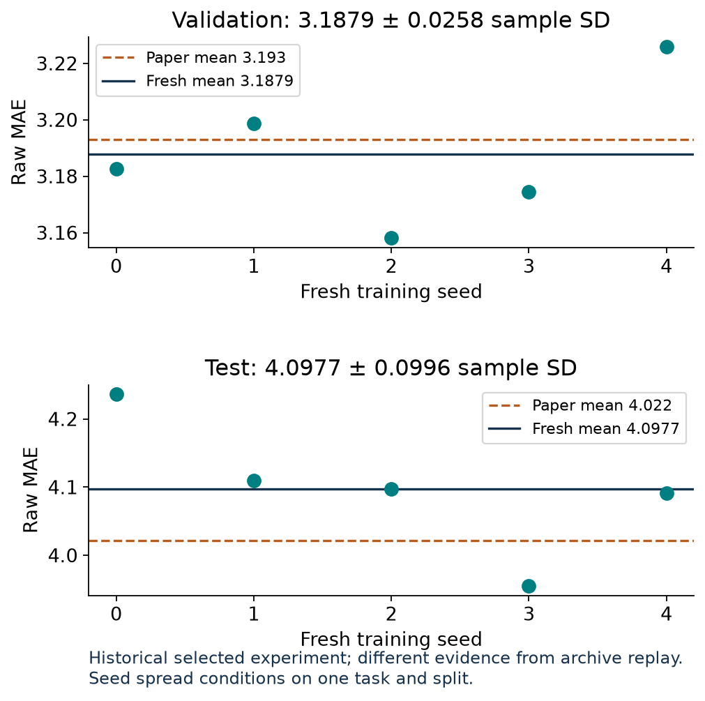

Measured primary fresh historical RDL fits, seeds 0–4; sample SD measures fitting variability on one split.

**Independent checks:** every saved prediction is rescored; checkpoint hashes are verified; query keys and targets are checked against the released task archive; graph relations are checked through independent SQL joins; the port’s outputs are compared with the original model on the same sampled batches.

> **Scope check.** The inherited `0.2 MAE` descriptive tolerance is descriptive. CLOSE is not statistical equivalence. The historical experiment is not the current GNN submission’s exact run and is not a retraining of Kapso or RT-PluRel. Whole-paper training and top-entry search reproduction remain outside the executed scope.

```python
# PROVIDED: independently rescore saved fresh-fit evidence, not a new training run.
TRAINING_PAYLOAD=json.loads(gzip.decompress(base64.b64decode('H4sIAAAAAAACA5S859LjSJIl+ipr9Rc7FdDi/iMJTSiCINTaWhtUQBBaA2Pz…=')))
training_rows=[];count=0
for key,item in TRAINING_PAYLOAD.items():
    raw=base64.b64decode(item['base64']);assert hashlib.sha256(raw).hexdigest()==item['sha256']
    a=np.load(io.BytesIO(raw));r=item['result']
    assert r['selected_epoch']==min(r['trace'],key=lambda t:t['val_mae'])['epoch']
    for split,expected in r['scores'].items():
        score=regression_score(a[split+'_target'],a[split+'_pred'],1.)
        assert abs(score['mae']-expected)<1e-12;count+=score['count']
    if key.startswith('final/'):
        assert len(r['trace'])==10 and all(x['train_queries']==7453 for x in r['trace'])
        training_rows.append(dict(seed=r['seed'],**r['scores']))
assert count==6794 and len(training_rows)==5
display(pd.DataFrame(training_rows));print('Fresh primary fit/pilot predictions rescored:',count)
```

|  | seed | val | test |
| --- | --- | --- | --- |
| 0 | 0 | 3.182544 | 4.236059 |
| 1 | 1 | 3.198574 | 4.109274 |
| 2 | 2 | 3.158045 | 4.097258 |
| 3 | 3 | 3.174528 | 3.955010 |
| 4 | 4 | 3.225945 | 4.090875 |

```
Fresh primary fit/pilot predictions rescored: 6794
```

## 8 · Write the claim you can defend

The deliverable is a short audit, not a screenshot of a rank. Include:

1. **Identity:** entry issue, source/data revisions, prediction hashes, query keys and canonical tasks.
2. **Measurement:** raw error, fixed normalization, per-task scores and aggregate; explain any mismatch.
3. **Setup difference:** one material input, selection, training or budget difference, with evidence.
4. **Claim boundary:** evaluation replay versus training reproduction versus controlled comparison.

**EXIT:** “We reproduced ___ from ___ under ___. We did not establish ___. Before attributing the score gap to the model, I would hold ___ fixed and measure ___.” Fill the blanks with this lesson’s actual artifacts. Explain why one F1 task cannot qualify a nine-task board.

Write your EXIT audit before consulting the model answer; paste it to the teacher for feedback.

**Return tomorrow:** reconstruct the normalization example from memory. In a week, audit another entry without looking at this checklist. For [Lesson 137](https://avistian.github.io/relational/lessons/0137-error-analysis-reg.html), retain the query keys: they will let you ask where errors concentrate instead of treating one mean as the whole story.

Ask the teaching agent any follow-up question, or paste your EXIT audit for feedback. Author-reference execution is complete evidence preparation; learner mastery remains pending.

**Carry this forward.** Keep the aligned query keys from your leaderboard audit. Lesson 137 uses them to locate errors that the overall mean hides. [Continue to Lesson 137](https://avistian.github.io/relational/lessons/0137-error-analysis-reg.html).

## Optional · Complete nine-task evaluation replay

OFF by default. This downloads official prediction archives and pinned train/test task tables, scores all 27 task-entry pairs, checks upstream alignment and metrics, and audits normalization. It uses your live functions. Allow several minutes and several hundred MB of download/cache space; it does not download full databases or train any model. The operator is visible below.

```python
RUN_FULL_LEADERBOARD_REPLAY = False
if RUN_FULL_LEADERBOARD_REPLAY:
    import urllib.request
    P=Path('l136-replay');S=P/'sources/l136';S.mkdir(parents=True,exist_ok=True)
    FROZEN_SOURCES = {'relbench_commit': '584a03d518b2b655580ea8e1cfbbb26bec0a2841', 'hf_revision': 'd8e976fd0a4b78877204bc8dfbcfc9a9f7f48600', 'kapso_commit': '30ddb51cb971a105f37d4089c447af59e3d1e861', 'files': {'leaderboard.json': {'url': 'https://raw.githubusercontent.com/stanford-star/relbench/584a03d518b2b655580ea8e1cfbbb26bec0a2841/leaderboard/leaderboard.json', 'sha256': 'c65824f61874b9317b188aca37262d9876457c6d18fcaa24a7d67f6f1fff096b', 'bytes': 25683}, 'submit.py': {'url': 'https://raw.githubusercontent.com/stanford-star/relbench/584a03d518b2b655580ea8e1cfbbb26bec0a2841/relbench/submit.py', 'sha256': '0fe31158cc8e89722a82af3da7dab29a9eac32266d7d25dc48f87573c4bb213f', 'bytes': 42771}, 'metrics.py': {'url': 'https://raw.githubusercontent.com/stanford-star/relbench/584a03d518b2b655580ea8e1cfbbb26bec0a2841/relbench/metrics.py', 'sha256': '8105ab73b84b7fffd7b5df1611b47b78b5fbea346d0178699848fcdd5c7c63ab', 'bytes': 2535}, 'task_entity.py': {'url': 'https://raw.githubusercontent.com/stanford-star/relbench/584a03d518b2b655580ea8e1cfbbb26bec0a2841/relbench/base/task_entity.py', 'sha256': 'ff663f15f1bd44c8ffad425e0e895f1b2c9c33ea4b20445405a3079db8cd4e5d', 'bytes': 6108}, 'LICENSE': {'url': 'https://raw.githubusercontent.com/stanford-star/relbench/584a03d518b2b655580ea8e1cfbbb26bec0a2841/LICENSE', 'sha256': '373b7c4e5ab541b3a753e1cff5643f494bbc2f6f6917d8fbd225de8ea7dbf3fc', 'bytes': 1080}, 'regression_stds.json': {'url': 'https://huggingface.co/datasets/stanford-star/relbench-v1/resolve/d8e976fd0a4b78877204bc8dfbcfc9a9f7f48600/regression_stds.json', 'sha256': '4ff31059268c6f180304be7c115151b80ba34d69fb84153e1cccf79cba074820', 'bytes': 1218}, 'kapso.zip': {'url': 'https://github.com/user-attachments/files/31459805/regression-kapso.zip', 'sha256': '0cf06df91b9b14be977c2d3f36a5f978b7103635cc047b89ff8bda5401f6c4dd', 'bytes': 4727355}, 'gnn.zip': {'url': 'https://github.com/user-attachments/files/31398757/gnn-regression.zip', 'sha256': '5506b1d6b337c861398f082f191871dda073c83bed6b8d51ba0c56c88acb7bfc', 'bytes': 4274935}, 'plurel.zip': {'url': 'https://github.com/user-attachments/files/31533926/rt-plurel-regression.zip', 'sha256': '68171043c3f42324a61d229244b800c3d880367e53912d9823ed3974de5f3f19', 'bytes': 6789880}, 'entry-393.json': {'url': 'https://raw.githubusercontent.com/stanford-star/relbench/584a03d518b2b655580ea8e1cfbbb26bec0a2841/leaderboard/entries/393.json', 'sha256': 'd3dff9f421688482c56e668e1eb5fe7315cad9ffb843b9d0626ebcc85fc013d0', 'bytes': 2071}, 'issue-393.json': {'url': 'https://api.github.com/repos/stanford-star/relbench/issues/393', 'sha256': 'b6ad85efab7bc91e94403853e4748a7f02983a6a5f54c0c4a1281a0ff6ccdafd', 'bytes': 4947}, 'entry-380.json': {'url': 'https://raw.githubusercontent.com/stanford-star/relbench/584a03d518b2b655580ea8e1cfbbb26bec0a2841/leaderboard/entries/380.json', 'sha256': '5e8ab9b5ba182da28cadc81ef1ea29081c5fb06ce90f6ec17618512648da8ed2', 'bytes': 2098}, 'issue-380.json': {'url': 'https://api.github.com/repos/stanford-star/relbench/issues/380', 'sha256': '809ada33f8f6c879d737dcbc5d2550c6d4b49bbfb798047edbaa20c83b8c68a6', 'bytes': 4801}, 'entry-397.json': {'url': 'https://raw.githubusercontent.com/stanford-star/relbench/584a03d518b2b655580ea8e1cfbbb26bec0a2841/leaderboard/entries/397.json', 'sha256': 'e6ec13d1ab32c606bac12716e10178c4c400a75d780e028337d545d7aec54e26', 'bytes': 1445}, 'issue-397.json': {'url': 'https://api.github.com/repos/stanford-star/relbench/issues/397', 'sha256': 'bfb5c8206ec3dfb36071e8787981c390deacd74adcab300fa6541d341b91eb2a', 'bytes': 4747}, 'kapso-README.md': {'url': 'https://raw.githubusercontent.com/Leeroo-AI/kapso/30ddb51cb971a105f37d4089c447af59e3d1e861/benchmarks/relbench/README.md', 'sha256': '0ffed55eaefa101359331c2c939630ecbed0e4d0b97b20aea71e426e64753568', 'bytes': 5072}, 'kapso-EVALUATION_PROTOCOL.md': {'url': 'https://raw.githubusercontent.com/Leeroo-AI/kapso/30ddb51cb971a105f37d4089c447af59e3d1e861/benchmarks/relbench/EVALUATION_PROTOCOL.md', 'sha256': '89a4454315d80975e04af665ddc89800a036ec20cf9b304aad66225be5b1dabc', 'bytes': 16632}}}
    for name,meta in FROZEN_SOURCES['files'].items():
        path=S/name
        if not path.exists():path.write_bytes(urllib.request.urlopen(meta['url'],timeout=90).read())
        assert hashlib.sha256(path.read_bytes()).hexdigest()==meta['sha256'],name
    (P/'_sources_l136.json').write_text(json.dumps(FROZEN_SOURCES,indent=2))
    """Rescore complete published regression archives with independent and source oracles."""
    import ast,hashlib,io,json,math,types,typing,urllib.request,zipfile
    from pathlib import Path
    import numpy as np
    import pandas as pd
    import yaml
    P=Path('l136-replay');S=P/'sources/l136';D=P/'results/l136/leaderboard-data';D.mkdir(parents=True,exist_ok=True)
    provenance=json.loads((P/'_sources_l136.json').read_text())
    for name,row in provenance['files'].items():assert hashlib.sha256((S/name).read_bytes()).hexdigest()==row['sha256'],name
    source=(S/'submit.py').read_text();tree=ast.parse(source)
    tasks=next(ast.literal_eval(n.value)['regression'] for n in tree.body if isinstance(n,ast.AnnAssign) and getattr(n.target,'id',None)=='LEADERBOARD_TASKS')
    ns=dict(pd=pd,np=np,Sequence=typing.Sequence)
    for n in tree.body:
     if isinstance(n,ast.FunctionDef) and n.name in ['_coerce_keys','_key_set','_validate_keys','_aligned_to_gt']:
      exec('from __future__ import annotations\n'+ast.get_source_segment(source,n),ns)
    metrics=types.ModuleType('pinned_metrics');exec(compile((S/'metrics.py').read_text(),str(S/'metrics.py'),'exec'),metrics.__dict__)
    stds=json.loads((S/'regression_stds.json').read_text())['stds'];datafiles={};results={};portable={};rows_total=0
    entries={393:'kapso',380:'gnn',397:'plurel'}
    boards={i:json.loads((S/f'entry-{i}.json').read_text()) for i in entries}
    archives={i:zipfile.ZipFile(S/(name+'.zip')) for i,name in entries.items()}
    base=f"https://huggingface.co/datasets/stanford-star/relbench-v1/resolve/{provenance['hf_revision']}/"
    def fetch(remote):
     path=D/remote;path.parent.mkdir(parents=True,exist_ok=True)
     if not path.exists():
      raw=urllib.request.urlopen(base+remote,timeout=90).read();path.write_bytes(raw)
     datafiles[remote]=dict(url=base+remote,sha256=hashlib.sha256(path.read_bytes()).hexdigest(),bytes=path.stat().st_size)
     return path
    for task in tasks:
     dataset,name=task.split('/');root=f'{dataset}/tasks/{name}'
     spec=yaml.safe_load(fetch(root+'/manifest.yaml').read_text());gt=pd.read_parquet(fetch(root+'/test.parquet'))
     keycols=[spec['entity_col'],spec['time_col']];target=spec['target_col']
     assert not gt[keycols].isna().any().any()
     expected=list(gt[keycols].itertuples(index=False,name=None));task_results={}
     # Verify hosted normalization from all train labels, not a convenience subset.
     train=pd.read_parquet(fetch(root+'/train.parquet'));calculated=float(train[target].std(ddof=1));std=stds[task]
     scale_verdict='CLOSE' if math.isclose(calculated,std,rel_tol=2e-6) else 'DIFFERS_FROM_HOSTED_CONSTANT'
     if scale_verdict!='CLOSE':print('Scale audit:',task,calculated,'vs hosted',std,flush=True)
     for issue,z in archives.items():
      csvname=task.replace('/','__')+'.csv';raw=z.read(csvname);df=pd.read_csv(io.BytesIO(raw));df=ns['_coerce_keys'](df,gt,keycols)
      ns['_validate_keys'](df,gt,keycols,target)
      source_pred=ns['_aligned_to_gt'](df,gt,keycols,target).to_numpy()
      supplied=list(df[keycols].itertuples(index=False,name=None))
      pred=np.array(align_predictions(expected,supplied,df[target].tolist()))
      np.testing.assert_array_equal(pred,source_pred)
      scores=regression_score(gt[target].tolist(),pred.tolist(),std)
      oracle=metrics.make_nmae(lambda:std)(gt[target].to_numpy(),source_pred)
      assert abs(scores['nmae']-oracle)<1e-12
      reported=boards[issue]['boards']['regression']['results'][task]
      assert abs(scores['nmae']-reported)<1e-10,(task,issue,scores,reported)
      scores.update(reported=reported,delta=scores['nmae']-reported,source_metric=oracle,prediction_csv_sha256=hashlib.sha256(raw).hexdigest())
      task_results[str(issue)]=scores;rows_total+=len(gt)
      if task=='rel-f1/driver-position':
       # Original-order rows exercise actual keyed alignment in the portable notebook.
       portable[str(issue)]=dict(name=boards[issue]['name'],keys=[[int(a),int(pd.Timestamp(b).value)] for a,b in supplied],pred=df[target].tolist(),reported=reported)
     results[task]=dict(keys=keycols,target=target,rows=len(gt),train_rows=len(train),hosted_train_std=std,recomputed_train_std=calculated,normalization_audit=scale_verdict,entries=task_results)
     if task=='rel-f1/driver-position':
      portable['truth']=dict(keys=[[int(a),int(pd.Timestamp(b).value)] for a,b in expected],target=gt[target].tolist(),train_std=std)
     print(task,len(gt),'rows × 3 entries: exact score replay',flush=True)
    aggregates={}
    for issue,entry in boards.items():
     values={t:results[t]['entries'][str(issue)]['nmae'] for t in tasks};mean=complete_board(values,tasks);reported=entry['boards']['regression']['mean'];assert abs(mean-reported)<1e-12
     aggregates[str(issue)]=dict(name=entry['name'],mean=mean,reported=reported,delta=mean-reported,tasks=len(tasks))
    summary=dict(status='COMPLETE_EVALUATION_REPLAY',canonical_tasks=tasks,entries=aggregates,tasks=results,predictions_rescored=rows_total,data_files=datafiles,source_commit=provenance['relbench_commit'],hf_revision=provenance['hf_revision'],upstream_alignment='EXACT_ALL_ROWS',metric_tolerance=1e-10,training_reproduction='NOT_ESTABLISHED',full_submission_cli='NOT_RUN; exact pinned alignment and metric functions executed',task_config_comparison='Current HF tasks; historical training identity separate')
    E=P/'evidence/l136';E.mkdir(parents=True,exist_ok=True)
    (E/'leaderboard.json').write_text(json.dumps(summary,indent=2));(E/'portable-f1.json').write_text(json.dumps(portable,separators=(',',':')))
    print(json.dumps(aggregates,indent=2));print('Predictions independently rescored:',rows_total)

else:
    print("Full nine-task replay NOT_RUN in this kernel; full author audit is provided above.")
```

```
Full nine-task replay NOT_RUN in this kernel; full author audit is provided above.
```

## PROVIDED · Full selected RDL model and trainer

This is the released basic RDL port, not the architecture of Kapso or RT-PluRel. Read typed feature encoding → relative-time addition → two relation-specific GraphSAGE layers → seed-only head. The blocks below are executable code, not a hidden import. Source: RelBench commit 9aa346267c2e1c560bd92da07d6f4ad1ca2f0639, MIT.

### PROVIDED · Key identities (PROVIDED)

```python
import numpy as np
```

### PROVIDED · Task 1: map foreign keys to row positions

```python
def foreign_key_edges(primary_keys, foreign_keys):
    lookup = {key: i for i, key in enumerate(primary_keys)}
    if len(lookup) != len(primary_keys):
        raise ValueError("Primary keys must be unique")
    pairs = []
    for source, key in enumerate(foreign_keys):
        if key is None or (isinstance(key, float) and np.isnan(key)):
            continue
        if key not in lookup:
            raise ValueError("Unknown foreign key")
        pairs.append((source, lookup[key]))
    return np.asarray(pairs, dtype=np.int64).reshape(-1, 2).T
```

### PROVIDED · Task 2: preserve one query cutoff across every hop

```python
def temporal_nodes(edges, times, seed, cutoff, hops):
    if times[seed] is not None and times[seed] > cutoff:
        raise ValueError("Seed is unavailable at the query time")
    seen, frontier = {seed}, {seed}
    for _ in range(hops):
        candidates = {dst for src, dst in edges if src in frontier
                      and (times[dst] is None or times[dst] <= cutoff)}
        frontier = candidates - seen
        seen |= candidates
    return sorted(seen)
```

### PROVIDED · Task 3: attach labels by query identity, not entity identity

```python
def query_targets(targets, input_id):
    return np.asarray(targets)[np.asarray(input_id, dtype=np.int64)]
```

### PROVIDED · Full released model dependencies (PROVIDED)

```python
from typing import Any, Dict, List, Optional

import torch
import torch_frame
from torch import Tensor
from torch_frame.data.stats import StatType
from torch_frame.nn.models import ResNet
from torch_geometric.nn import HeteroConv, LayerNorm, PositionalEncoding, SAGEConv
from torch_geometric.typing import EdgeType, NodeType


class HeteroEncoder(torch.nn.Module):
    r"""HeteroEncoder based on PyTorch Frame.

    Args:
        channels (int): The output channels for each node type.
        node_to_col_names_dict (Dict[NodeType, Dict[torch_frame.stype, List[str]]]):
            A dictionary mapping from node type to column names dictionary
            compatible to PyTorch Frame.
        torch_frame_model_cls: Model class for PyTorch Frame. The class object
            takes :class:`TensorFrame` object as input and outputs
            :obj:`channels`-dimensional embeddings. Default to
            :class:`torch_frame.nn.ResNet`.
        torch_frame_model_kwargs (Dict[str, Any]): Keyword arguments for
            :class:`torch_frame_model_cls` class. Default keyword argument is
            set specific for :class:`torch_frame.nn.ResNet`. Expect it to
            be changed for different :class:`torch_frame_model_cls`.
        default_stype_encoder_cls_kwargs (Dict[torch_frame.stype, Any]):
            A dictionary mapping from :obj:`torch_frame.stype` object into a
            tuple specifying :class:`torch_frame.nn.StypeEncoder` class and its
            keyword arguments :obj:`kwargs`.
    """

    def __init__(
        self,
        channels: int,
        node_to_col_names_dict: Dict[NodeType, Dict[torch_frame.stype, List[str]]],
        node_to_col_stats: Dict[NodeType, Dict[str, Dict[StatType, Any]]],
        torch_frame_model_cls=ResNet,
        torch_frame_model_kwargs: Dict[str, Any] = {
            "channels": 128,
            "num_layers": 4,
        },
        default_stype_encoder_cls_kwargs: Dict[torch_frame.stype, Any] = {
            torch_frame.categorical: (torch_frame.nn.EmbeddingEncoder, {}),
            torch_frame.numerical: (torch_frame.nn.LinearEncoder, {}),
            torch_frame.multicategorical: (
                torch_frame.nn.MultiCategoricalEmbeddingEncoder,
                {},
            ),
            torch_frame.embedding: (torch_frame.nn.LinearEmbeddingEncoder, {}),
            torch_frame.timestamp: (torch_frame.nn.TimestampEncoder, {}),
        },
    ):
        super().__init__()

        self.encoders = torch.nn.ModuleDict()

        for node_type in node_to_col_names_dict.keys():
            stype_encoder_dict = {
                stype: default_stype_encoder_cls_kwargs[stype][0](
                    **default_stype_encoder_cls_kwargs[stype][1]
                )
                for stype in node_to_col_names_dict[node_type].keys()
            }
            torch_frame_model = torch_frame_model_cls(
                **torch_frame_model_kwargs,
                out_channels=channels,
                col_stats=node_to_col_stats[node_type],
                col_names_dict=node_to_col_names_dict[node_type],
                stype_encoder_dict=stype_encoder_dict,
            )
            self.encoders[node_type] = torch_frame_model

    def reset_parameters(self):
        for encoder in self.encoders.values():
            encoder.reset_parameters()

    def forward(
        self,
        tf_dict: Dict[NodeType, torch_frame.TensorFrame],
    ) -> Dict[NodeType, Tensor]:
        x_dict = {
            node_type: self.encoders[node_type](tf) for node_type, tf in tf_dict.items()
        }
        return x_dict


class HeteroTemporalEncoder(torch.nn.Module):
    def __init__(self, node_types: List[NodeType], channels: int):
        super().__init__()

        self.encoder_dict = torch.nn.ModuleDict(
            {node_type: PositionalEncoding(channels) for node_type in node_types}
        )
        self.lin_dict = torch.nn.ModuleDict(
            {node_type: torch.nn.Linear(channels, channels) for node_type in node_types}
        )

    def reset_parameters(self):
        for encoder in self.encoder_dict.values():
            encoder.reset_parameters()
        for lin in self.lin_dict.values():
            lin.reset_parameters()

    def forward(
        self,
        seed_time: Tensor,
        time_dict: Dict[NodeType, Tensor],
        batch_dict: Dict[NodeType, Tensor],
    ) -> Dict[NodeType, Tensor]:
        out_dict: Dict[NodeType, Tensor] = {}

        for node_type, time in time_dict.items():
            rel_time = seed_time[batch_dict[node_type]] - time
            rel_time = rel_time / (60 * 60 * 24)  # Convert seconds to days.

            x = self.encoder_dict[node_type](rel_time)
            x = self.lin_dict[node_type](x)
            out_dict[node_type] = x

        return out_dict


class HeteroGraphSAGE(torch.nn.Module):
    def __init__(
        self,
        node_types: List[NodeType],
        edge_types: List[EdgeType],
        channels: int,
        aggr: str = "mean",
        num_layers: int = 2,
    ):
        super().__init__()

        self.convs = torch.nn.ModuleList()
        for _ in range(num_layers):
            conv = HeteroConv(
                {
                    edge_type: SAGEConv((channels, channels), channels, aggr=aggr)
                    for edge_type in edge_types
                },
                aggr="sum",
            )
            self.convs.append(conv)

        self.norms = torch.nn.ModuleList()
        for _ in range(num_layers):
            norm_dict = torch.nn.ModuleDict()
            for node_type in node_types:
                norm_dict[node_type] = LayerNorm(channels, mode="node")
            self.norms.append(norm_dict)

    def reset_parameters(self):
        for conv in self.convs:
            conv.reset_parameters()
        for norm_dict in self.norms:
            for norm in norm_dict.values():
                norm.reset_parameters()

    def forward(
        self,
        x_dict: Dict[NodeType, Tensor],
        edge_index_dict: Dict[NodeType, Tensor],
        num_sampled_nodes_dict: Optional[Dict[NodeType, List[int]]] = None,
        num_sampled_edges_dict: Optional[Dict[EdgeType, List[int]]] = None,
    ) -> Dict[NodeType, Tensor]:
        for _, (conv, norm_dict) in enumerate(zip(self.convs, self.norms)):
            x_dict = conv(x_dict, edge_index_dict)
            x_dict = {key: norm_dict[key](x) for key, x in x_dict.items()}
            x_dict = {key: x.relu() for key, x in x_dict.items()}

        return x_dict
```

### PROVIDED · Relational node predictor (PROVIDED)

```python
from typing import Any, Dict, List

import torch
from torch import Tensor
from torch.nn import Embedding, ModuleDict
from torch_frame.data.stats import StatType
from torch_geometric.data import HeteroData
from torch_geometric.nn import MLP
from torch_geometric.typing import NodeType




class Model(torch.nn.Module):

    def __init__(
        self,
        data: HeteroData,
        col_stats_dict: Dict[str, Dict[str, Dict[StatType, Any]]],
        num_layers: int,
        channels: int,
        out_channels: int,
        aggr: str,
        norm: str,
        # List of node types to add shallow embeddings to input
        shallow_list: List[NodeType] = [],
        # ID awareness
        id_awareness: bool = False,
    ):
        super().__init__()

        self.encoder = HeteroEncoder(
            channels=channels,
            node_to_col_names_dict={
                node_type: data[node_type].tf.col_names_dict
                for node_type in data.node_types
            },
            node_to_col_stats=col_stats_dict,
        )
        self.temporal_encoder = HeteroTemporalEncoder(
            node_types=[
                node_type for node_type in data.node_types if "time" in data[node_type]
            ],
            channels=channels,
        )
        self.gnn = HeteroGraphSAGE(
            node_types=data.node_types,
            edge_types=data.edge_types,
            channels=channels,
            aggr=aggr,
            num_layers=num_layers,
        )
        self.head = MLP(
            channels,
            out_channels=out_channels,
            norm=norm,
            num_layers=1,
        )
        self.embedding_dict = ModuleDict(
            {
                node: Embedding(data.num_nodes_dict[node], channels)
                for node in shallow_list
            }
        )

        self.id_awareness_emb = None
        if id_awareness:
            self.id_awareness_emb = torch.nn.Embedding(1, channels)
        self.reset_parameters()

    def reset_parameters(self):
        self.encoder.reset_parameters()
        self.temporal_encoder.reset_parameters()
        self.gnn.reset_parameters()
        self.head.reset_parameters()
        for embedding in self.embedding_dict.values():
            torch.nn.init.normal_(embedding.weight, std=0.1)
        if self.id_awareness_emb is not None:
            self.id_awareness_emb.reset_parameters()

    def forward(
        self,
        batch: HeteroData,
        entity_table: NodeType,
    ) -> Tensor:
        seed_time = batch[entity_table].seed_time
        x_dict = self.encoder(batch.tf_dict)

        rel_time_dict = self.temporal_encoder(
            seed_time, batch.time_dict, batch.batch_dict
        )

        for node_type, rel_time in rel_time_dict.items():
            x_dict[node_type] = x_dict[node_type] + rel_time

        for node_type, embedding in self.embedding_dict.items():
            x_dict[node_type] = x_dict[node_type] + embedding(batch[node_type].n_id)

        x_dict = self.gnn(
            x_dict,
            batch.edge_index_dict,
            batch.num_sampled_nodes_dict,
            batch.num_sampled_edges_dict,
        )

        return self.head(x_dict[entity_table][: seed_time.size(0)])
```

### PROVIDED · Full database to REG and query transform (PROVIDED)

```python
import os
from typing import Any, Dict, NamedTuple, Optional, Tuple

import numpy as np
import pandas as pd
import torch
from torch import Tensor
from torch_frame import stype
from torch_frame.config import TextEmbedderConfig
from torch_frame.data import Dataset
from torch_frame.data.stats import StatType
from torch_geometric.data import HeteroData
from torch_geometric.typing import NodeType
from torch_geometric.utils import sort_edge_index

from relbench.base import Database, EntityTask, RecommendationTask, Table, TaskType
from relbench.modeling.utils import remove_pkey_fkey, to_unix_time


def make_pkey_fkey_graph(
    db: Database,
    col_to_stype_dict: Dict[str, Dict[str, stype]],
    text_embedder_cfg: Optional[TextEmbedderConfig] = None,
    cache_dir: Optional[str] = None,
) -> Tuple[HeteroData, Dict[str, Dict[str, Dict[StatType, Any]]]]:
    r"""Given a :class:`Database` object, construct a heterogeneous graph with primary-
    foreign key relationships, together with the column stats of each table.

    Args:
        db: A database object containing a set of tables.
        col_to_stype_dict: Column to stype for
            each table.
        text_embedder_cfg: Text embedder config.
        cache_dir: A directory for storing materialized tensor
            frames. If specified, we will either cache the file or use the
            cached file. If not specified, we will not use cached file and
            re-process everything from scratch without saving the cache.

    Returns:
        HeteroData: The heterogeneous :class:`PyG` object with
            :class:`TensorFrame` feature.
    """
    data = HeteroData()
    col_stats_dict = dict()
    if cache_dir is not None:
        os.makedirs(cache_dir, exist_ok=True)

    for table_name, table in db.table_dict.items():
        # Materialize the tables into tensor frames:
        df = table.df
        # Ensure that pkey is consecutive.
        if table.pkey_col is not None:
            assert (df[table.pkey_col].values == np.arange(len(df))).all()

        col_to_stype = col_to_stype_dict[table_name]

        # Remove pkey, fkey columns since they will not be used as input
        # feature.
        remove_pkey_fkey(col_to_stype, table)

        if len(col_to_stype) == 0:  # Add constant feature in case df is empty:
            col_to_stype = {"__const__": stype.numerical}
            # We need to add edges later, so we need to also keep the fkeys
            fkey_dict = {key: df[key] for key in table.fkey_col_to_pkey_table}
            df = pd.DataFrame({"__const__": np.ones(len(table.df)), **fkey_dict})

        path = (
            None if cache_dir is None else os.path.join(cache_dir, f"{table_name}.pt")
        )

        dataset = Dataset(
            df=df,
            col_to_stype=col_to_stype,
            col_to_text_embedder_cfg=text_embedder_cfg,
        ).materialize(path=path)

        data[table_name].tf = dataset.tensor_frame
        col_stats_dict[table_name] = dataset.col_stats

        # Add time attribute:
        if table.time_col is not None:
            data[table_name].time = torch.from_numpy(
                to_unix_time(table.df[table.time_col])
            )

        # Add edges:
        for fkey_name, pkey_table_name in table.fkey_col_to_pkey_table.items():
            pkey_index = df[fkey_name]
            # Filter out dangling foreign keys
            mask = ~pkey_index.isna()
            fkey_index = torch.arange(len(pkey_index))
            # Filter dangling foreign keys:
            pkey_index = torch.from_numpy(pkey_index[mask].astype(int).values)
            fkey_index = fkey_index[torch.from_numpy(mask.values)]
            # Ensure no dangling fkeys
            assert (pkey_index < len(db.table_dict[pkey_table_name])).all()

            # fkey -> pkey edges
            edge_index = torch.stack([fkey_index, pkey_index], dim=0)
            edge_type = (table_name, f"f2p_{fkey_name}", pkey_table_name)
            data[edge_type].edge_index = sort_edge_index(edge_index)

            # pkey -> fkey edges.
            # "rev_" is added so that PyG loader recognizes the reverse edges
            edge_index = torch.stack([pkey_index, fkey_index], dim=0)
            edge_type = (pkey_table_name, f"rev_f2p_{fkey_name}", table_name)
            data[edge_type].edge_index = sort_edge_index(edge_index)

    data.validate()

    return data, col_stats_dict


class AttachTargetTransform:
    r"""Attach the target label to the heterogeneous mini-batch.

    The batch consists of disjoins subgraphs loaded via temporal sampling. The same
    input node can occur multiple times with different timestamps, and thus different
    subgraphs and labels. Hence labels cannot be stored in the graph object directly,
    and must be attached to the batch after the batch is created.
    """

    def __init__(self, entity: str, target: Tensor):
        self.entity = entity
        self.target = target

    def __call__(self, batch: HeteroData) -> HeteroData:
        batch[self.entity].y = self.target[batch[self.entity].input_id]
        return batch


class NodeTrainTableInput(NamedTuple):
    r"""Training table input for node prediction.

    - nodes is a Tensor of node indices.
    - time is a Tensor of node timestamps.
    - target is a Tensor of node labels.
    - transform attaches the target to the batch.
    """

    nodes: Tuple[NodeType, Tensor]
    time: Optional[Tensor]
    target: Optional[Tensor]
    transform: Optional[AttachTargetTransform]


def get_node_train_table_input(
    table: Table,
    task: EntityTask,
) -> NodeTrainTableInput:
    r"""Get the training table input for node prediction."""

    nodes = torch.from_numpy(table.df[task.entity_col].astype(int).values)

    time: Optional[Tensor] = None
    if table.time_col is not None:
        time = torch.from_numpy(to_unix_time(table.df[table.time_col]))

    target: Optional[Tensor] = None
    transform: Optional[AttachTargetTransform] = None
    if task.target_col in table.df:
        target_type = float
        if task.task_type == TaskType.MULTICLASS_CLASSIFICATION:
            target_type = int
        if task.task_type == TaskType.MULTILABEL_CLASSIFICATION:
            target = torch.from_numpy(np.stack(table.df[task.target_col].values))
        else:
            target = torch.from_numpy(
                table.df[task.target_col].values.astype(target_type)
            )
        transform = AttachTargetTransform(task.entity_table, target)

    return NodeTrainTableInput(
        nodes=(task.entity_table, nodes),
        time=time,
        target=target,
        transform=transform,
    )
```

```python
"""Released-loader audit: source identity, node cutoff and disjoint queries."""
import torch

def audit_batch(batch, graph, entity):
    roots=batch[entity].seed_time
    dated=edges=0
    for kind in batch.node_types:
        store=batch[kind]
        assert store.batch.shape==store.n_id.shape
        assert (store.batch>=0).all() and (store.batch<len(roots)).all()
        if 'time' in graph[kind]:
            expected=graph[kind].time[store.n_id.cpu()].to(store.time.device)
            assert torch.equal(store.time,expected), 'Timestamp no longer belongs to this global node'
            assert (store.time<=roots[store.batch]).all(), 'Future node at its root query cutoff'
            dated+=len(store.time)
    for kind in batch.edge_types:
        src,_,dst=kind;store=batch[kind];a,b=store.edge_index
        assert torch.equal(batch[src].batch[a],batch[dst].batch[b]), 'Cross-query edge'
        actual=torch.stack([batch[src].n_id[a],batch[dst].n_id[b]]).cpu()
        expected=graph[kind].edge_index[:,store.e_id.cpu()]
        assert torch.equal(actual,expected), 'Wrong original edge identity'
        edges+=len(a)
    n=batch[entity].batch_size
    assert torch.equal(batch[entity].batch[:n],torch.arange(n,device=roots.device))
    return dict(batches=1,queries=n,dated_node_occurrences=dated,edge_occurrences=edges)
```

### PROVIDED · Full validation-selected trainer

Trace the optimizer, seed-only L1 loss, full-query epoch, first-best checkpoint, restored evaluation, temporal batch audit and original-model parity. Here the configuration is fixed; this lesson does not repeat L135’s tuning search.

```python
"""Full trainer: minimal parameterization of pinned L117 released replay.
Search mode never asks the task for a test table and has no test loader.
"""
import copy, hashlib, json, time
from pathlib import Path
import numpy as np
import torch
from torch_geometric.loader import NeighborLoader
from torch_geometric.seed import seed_everything
BASE_CONFIG = {'channels': 128, 'num_layers': 2, 'batch_size': 512, 'lr': 0.005, 'epochs': 10, 'fanout': [128, 64], 'aggr': 'sum', 'temporal_strategy': 'uniform'}

def fit_tuning(data, stats, task, seed, output, epochs=10, device="cuda", original_model=None, *, configuration, evaluate_test=False):
    """Train all query rows; select first lowest validation MAE, replay all outputs."""
    seed_everything(seed)
    CONFIG = dict(BASE_CONFIG, lr=configuration["lr"], fanout=configuration["fanout"], epochs=epochs)
    splits = ["train","val","test"] if evaluate_test else ["train","val"]
    audit_counts = {s:dict(batches=0,queries=0,dated_node_occurrences=0,edge_occurrences=0) for s in splits}
    output=Path(output);output.mkdir(parents=True,exist_ok=True)
    start=time.perf_counter()
    loaders={}
    tables={s:task.get_table(s,mask_input_cols=False) for s in splits}
    for split in tables:
        # Test labels are for independent scoring, never attached to model input.
        inp=get_node_train_table_input(task.get_table(split),task)
        loaders[split]=NeighborLoader(data,num_neighbors=CONFIG['fanout'],
            time_attr='time',input_nodes=inp.nodes,input_time=inp.time,
            transform=inp.transform,batch_size=512,temporal_strategy='uniform',
            shuffle=split=='train',num_workers=0)
    model=Model(data,stats,num_layers=2,channels=128,out_channels=1,aggr='sum',norm='batch_norm').to(device)
    optimizer=torch.optim.Adam(model.parameters(),lr=CONFIG['lr'])
    bounds=np.percentile(tables['train'].df[task.target_col].to_numpy(),[2,98])
    best=float('inf');state=None;trace=[]
    @torch.no_grad()
    def predict(loader,reference=None):
        model.eval();out=[];max_error=0.;nodes=0
        for batch in loader:
            split=next(s for s,l in loaders.items() if l is loader)
            report=audit_batch(batch,data,task.entity_table)
            for k,v in report.items():audit_counts[split][k]+=v
            batch=batch.to(device)
            # Every dated sampled row obeys its root query timestamp.
            for kind,stamp in batch.time_dict.items():
                assert (stamp<=batch[task.entity_table].seed_time[batch[kind].batch]).all()
            value=model(batch,task.entity_table)
            if reference is not None:
                other=reference(batch,task.entity_table)
                torch.testing.assert_close(value,other,rtol=1e-5,atol=1e-5)
                max_error=max(max_error,float((value-other).abs().max()))
            out.append(value.clamp(*bounds).view(-1).cpu().numpy())
            nodes+=sum(batch.num_nodes_dict.values())
        return np.concatenate(out),max_error,nodes
    for epoch in range(1,epochs+1):
        model.train();loss_sum=0.;count=0
        for batch in loaders['train']:
            report=audit_batch(batch,data,task.entity_table)
            for k,v in report.items():audit_counts['train'][k]+=v
            batch=batch.to(device);optimizer.zero_grad()
            pred=model(batch,task.entity_table).view(-1)
            loss=torch.nn.functional.l1_loss(pred.float(),batch[task.entity_table].y.float())
            loss.backward();optimizer.step()
            count+=len(pred);loss_sum+=float(loss.detach())*len(pred)
        assert count==7453
        val,_,_=predict(loaders['val'])
        score=float(np.mean(np.abs(val-tables['val'].df[task.target_col].to_numpy())))
        trace.append(dict(epoch=epoch,train_mae=loss_sum/count,val_mae=score,train_queries=count))
        if score<best:best=score;state=copy.deepcopy(model.state_dict());selected=epoch
        print(json.dumps(trace[-1]),flush=True)
    model.load_state_dict(state);model.eval()
    torch.save(state,output/'selected.pt')
    # Reference construction consumes RNG; save/restore to preserve sampler sequence.
    rng=torch.get_rng_state();cuda_rng=torch.cuda.get_rng_state_all() if torch.cuda.is_available() else None
    reference=None
    if original_model is not None:
        reference=original_model(data,stats,num_layers=2,channels=128,out_channels=1,aggr='sum',norm='batch_norm').to(device)
        reference.load_state_dict(state);reference.eval()
    torch.set_rng_state(rng)
    if cuda_rng is not None:torch.cuda.set_rng_state_all(cuda_rng)
    scores={};replays={};arrays={}
    for split in (['val','test'] if evaluate_test else ['val']):
        pred,err,nodes=predict(loaders[split],reference)
        target=tables[split].df[task.target_col].to_numpy()
        scores[split]=float(np.mean(np.abs(pred-target)))
        official=task.evaluate(pred,tables[split])['mae']
        assert abs(scores[split]-official)<1e-10
        arrays[split+'_pred']=pred;arrays[split+'_target']=target
        arrays[split+'_entity']=tables[split].df[task.entity_col].to_numpy()
        arrays[split+'_time']=tables[split].df[task.time_col].astype('int64').to_numpy()
        replays[split]=dict(queries=len(pred),max_original_logit_error=err,sampled_nodes=nodes)
    np.savez_compressed(output/'predictions.npz',**arrays)
    result=dict(seed=seed,epochs=epochs,selected_epoch=selected,selection_mae=best,
        scores=scores,replay=replays,trace=trace,clamp=bounds.tolist(),seconds=time.perf_counter()-start,
        protocol=CONFIG,checkpoint_sha256=hashlib.sha256((output/'selected.pt').read_bytes()).hexdigest())
    result.update(configuration=configuration, evaluate_test=evaluate_test, temporal_audit=audit_counts)
    (output/'result.json').write_text(json.dumps(result,indent=2));return result
```

## Optional · Full five-seed historical training reproduction

OFF by default. Requires the exact documented GPU runtime. Runs all five seeds on full data through the visible model/trainer. Your `regression_score` checks every resulting prediction. Use the Modal operator for enforced dollar reservations; this notebook switch alone does not enforce a dollar cap. The independent GPU check of this notebook is separate from the primary fits.

```python
TEXT_SPEC = {'model': 'sentence-transformers/average_word_embeddings_glove.6B.300d', 'revision': 'e5e8fec6971be8960cfaa853a77a6ddc62a265d7'}
ORIGINAL_MODEL_SOURCE = 'from typing import Any, Dict, List\n\nimport torch\nfrom torch import Tensor\nfrom torch.nn import Embedding, ModuleDict\nfrom torch_frame.data.stats import StatType\nfrom torch_geometric.data import HeteroData\nfrom torch_geometric.nn import MLP\nfrom torch_geometric.typing import NodeType\n\nfrom relbench.modeling.nn import HeteroEncoder, HeteroGraphSAGE, HeteroTemporalEncoder\n\n\nclass Model(torch.nn.Module):\n\n    def __init__(\n        self,\n        data: HeteroData,\n        col_stats_dict: Dict[str, Dict[str, Dict[StatType, Any]]],\n        num_layers: int,\n        channels: int,\n        out_channels: int,\n        aggr: str,\n        norm: str,\n        # List of node types to add shallow embeddings to input\n        shallow_list: List[NodeType] = [],\n        # ID awareness\n        id_awareness: bool = False,\n    ):\n        super().__init__()\n\n        self.encoder = HeteroEncoder(\n            channels=channels,\n            node_to_col_names_dict={\n                node_type: data[node_type].tf.col_names_dict\n                for node_type in data.node_types\n            },\n            node_to_col_stats=col_stats_dict,\n        )\n        self.temporal_encoder = HeteroTemporalEncoder(\n            node_types=[\n                node_type for node_type in data.node_types if "time" in data[node_type]\n            ],\n            channels=channels,\n        )\n        self.gnn = HeteroGraphSAGE(\n            node_types=data.node_types,\n            edge_types=data.edge_types,\n            channels=channels,\n            aggr=aggr,\n            num_layers=num_layers,\n        )\n        self.head = MLP(\n            channels,\n            out_channels=out_channels,\n            norm=norm,\n            num_layers=1,\n        )\n        self.embedding_dict = ModuleDict(\n            {\n                node: Embedding(data.num_nodes_dict[node], channels)\n                for node in shallow_list\n            }\n        )\n\n        self.id_awareness_emb = None\n        if id_awareness:\n            self.id_awareness_emb = torch.nn.Embedding(1, channels)\n        self.reset_parameters()\n\n    def reset_parameters(self):\n        self.encoder.reset_parameters()\n        self.temporal_encoder.reset_parameters()\n        self.gnn.reset_parameters()\n        self.head.reset_parameters()\n        for embedding in self.embedding_dict.values():\n            torch.nn.init.normal_(embedding.weight, std=0.1)\n        if self.id_awareness_emb is not None:\n            self.id_awareness_emb.reset_parameters()\n\n    def forward(\n        self,\n        batch: HeteroData,\n        entity_table: NodeType,\n    ) -> Tensor:\n        seed_time = batch[entity_table].seed_time\n        x_dict = self.encoder(batch.tf_dict)\n\n        rel_time_dict = self.temporal_encoder(\n            seed_time, batch.time_dict, batch.batch_dict\n        )\n\n        for node_type, rel_time in rel_time_dict.items():\n            x_dict[node_type] = x_dict[node_type] + rel_time\n\n        for node_type, embedding in self.embedding_dict.items():\n            x_dict[node_type] = x_dict[node_type] + embedding(batch[node_type].n_id)\n\n        x_dict = self.gnn(\n            x_dict,\n            batch.edge_index_dict,\n            batch.num_sampled_nodes_dict,\n            batch.num_sampled_edges_dict,\n        )\n\n        return self.head(x_dict[entity_table][: seed_time.size(0)])\n\n    def forward_dst_readout(\n        self,\n        batch: HeteroData,\n        entity_table: NodeType,\n        dst_table: NodeType,\n    ) -> Tensor:\n        if self.id_awareness_emb is None:\n            raise RuntimeError(\n                "id_awareness must be set True to use forward_dst_readout"\n            )\n        seed_time = batch[entity_table].seed_time\n        x_dict = self.encoder(batch.tf_dict)\n        # Add ID-awareness to the root node\n        x_dict[entity_table][: seed_time.size(0)] += self.id_awareness_emb.weight\n\n        rel_time_dict = self.temporal_encoder(\n            seed_time, batch.time_dict, batch.batch_dict\n        )\n\n        for node_type, rel_time in rel_time_dict.items():\n            x_dict[node_type] = x_dict[node_type] + rel_time\n\n        for node_type, embedding in self.embedding_dict.items():\n            x_dict[node_type] = x_dict[node_type] + embedding(batch[node_type].n_id)\n\n        x_dict = self.gnn(\n            x_dict,\n            batch.edge_index_dict,\n        )\n\n        return self.head(x_dict[dst_table])\n'
```

```python
# This source is embedded by the builder after visible model/trainer definitions.
RUN_FULL_REPRODUCTION = False
if RUN_FULL_REPRODUCTION:
    assert not Path('l136-full').exists(), 'Use a fresh output directory'
    assert torch.cuda.is_available(), 'Full experiment requires the documented GPU runtime'
    import pyg_lib, importlib.metadata
    for package,version in {'torch':'2.5.1','relbench':'1.1.0','pytorch-frame':'0.2.3','torch-geometric':'2.6.1','sentence-transformers':'3.3.1','numpy':'1.26.4','pandas':'2.2.3'}.items():
        assert importlib.metadata.version(package).split('+')[0]==version, 'Use the pinned runtime: '+package
    from relbench.datasets import get_dataset
    from relbench.tasks import get_task
    from relbench.modeling.utils import get_stype_proposal
    from sentence_transformers import SentenceTransformer
    torch.set_num_threads(1);seed_everything(42)
    dataset=get_dataset('rel-f1',download=True);db=dataset.get_db()
    task=get_task('rel-f1','driver-position',download=True)
    for name,expected in [('db.zip','ec31a4e1bc2b2f9c36c05fcd3dfe2a40a506f335dc51ce79c3ec8bb40feb1482'),('tasks/driver-position.zip','775b28a51604169539bbe712a2f0d15158c112bc6abf316cdd0995087a7ae03e')]:
        assert hashlib.sha256((Path(dataset.cache_dir)/name).read_bytes()).hexdigest()==expected
    types=get_stype_proposal(db)
    text_model=SentenceTransformer(TEXT_SPEC['model'],revision=TEXT_SPEC['revision'],device='cpu')
    def embed(strings):return torch.from_numpy(text_model.encode(strings,show_progress_bar=False))
    data,stats=make_pkey_fkey_graph(db,types,TextEmbedderConfig(text_embedder=embed,batch_size=256))
    del text_model
    original={};exec(ORIGINAL_MODEL_SOURCE,original)
    root=Path('l136-full');root.mkdir();records=[]
    configuration=dict(id='lr005-full',lr=.005,fanout=[128,64])
    for seed in range(5):
        output=root/f'seed-{seed}'
        r=fit_tuning(data,stats,task,seed,output,10,'cuda',original['Model'],configuration=configuration,evaluate_test=True)
        a=np.load(output/'predictions.npz')
        for split in ['val','test']:
            score=regression_score(a[split+'_target'],a[split+'_pred'],1.)['mae']
            assert abs(score-r['scores'][split])<1e-12
        records.append(dict(seed=seed,scores=r['scores']))
    packet=dict(status='PASS',final_fits=len(records),records=records)
    (root/'packet.json').write_text(json.dumps(packet,indent=2));print(packet)
else:
    print('Full training NOT_RUN in this kernel. Author evidence is replayed separately.')
```

```
Full training NOT_RUN in this kernel. Author evidence is replayed separately.
```